# Projeto - Aprendizagem Estatística de Máquina II

2023-06-16

Nomes: Ana Paula Ferreira Simões, Paulo Luis Ramalho Mateus Filho e Samuel Rocha Mapurunga

#### 0. Bibliotecas e dados utilizados

```r
library(tidyverse)
library(tidymodels)
library(readxl)
library(janitor)
library(modeltime)
library(lubridate)
library(ggplot2)
library(timetk)
library(modeltime.ensemble)
library(stringi)
library(factoextra)
library(ggrepel)
library(cluster)
```

#### 1. Leitura dos dados utilizados

> Dados retirados do Kaggle: https://www.kaggle.com/datasets/lashagoch/life-expectancy-who-updated?datasetId=3065197&sortBy=dateRun&tab=bookmarked

> Os dados possuem 2864 linhas e 21 colunas.

```r
dados <- read_csv("Life Expectancy Data.csv")
```

#### 2. Tratamento dos dados

> A base apresenta as seguintes colunas:  
> Country - País (chr)  
> Region - Regiões (África, Ásia, Oceania, União Europeia, Oriente Médio, América Central e Caribe, América do Norte, América do Sul, Resto da Europa) (chr)  
> Year - Ano (dbl)  
> Infant_deaths - Número de mortes em bebês a cada 1000 pessoas da população (dbl)  
> Under_five_deaths - Número de mortes de crianças abaixo de 5 anos a cada 1000 pessoas da população (dbl)  
> Adult_mortality - Número de mortes de adultos a cada 1000 pessoas da população (dbl)  
> Alcohol_consumption - Consumo de álcool (em litros de puro álcool) per capita, em pessoas de 15 anos ou mais (dbl)  
> Hepatitis_B - Cobertura de imunização da hepatite B em crianças de 1 ano (dbl)  
> Measles - Cobertura da vacina contra sarampo (1a dose) em crianças de 1 ano (dbl)  
> BMI - IMC médio da população (dbl)  
> Polio - Cobertura de imunização contra polio em crianças de 1 ano (dbl)  
> Diphtheria - Cobertura de imunização diphtheria tetanus toxoid e pertussis em crianças de 1 ano (dbl)  
> Incidents_HIV - Incidentes de HIV na população entre 15 e 49 anos (dbl)  
> GDP_per_capita - PIB per capita em USD (dbl)  
> Population_mln - População (em milhões) (dbl)  
> Thinness_ten_nineteen_years - Prevalência de magreza entre adolescentes de 10 a 19 anos (dbl)  
> Thinness_five_nine_years - Prevalência de magreza entre crianças de 5 a 9 anos (dbl)  
> Schooling - Média de anos que pessoas de 25+ anos gastaram em educação formal (dbl)  
> Economy_status_Developed - País desenvolvido ou não (dbl)  
> Economy_status_Developing - País em desenvolvimento ou não (dbl)  
> Life_expectancy - Expectativa de vida (em anos) (dbl)

> Tratamento inicial da base de dados, limpeza do header, transformação da coluna de status desenvolvido para categoria, transformação do year para data unix e divisão entre base de desenvolvidos e sub-desenvolvidos.

> A divisão entre países desenvolvidos e sub-desenvolvidos é feita porque em países desenvolvidos as variáveis que têm maior correlação para a mudança na expectativa de vida é diferente das variáveis dos países sub-desenvolvidos.

```r
dados <- clean_names(dados)

dados <- subset(dados, select = -c(economy_status_developing))

dados$economy_status_developed <- as.factor(dados$economy_status_developed)
dados$year <- ymd(sprintf("%d-01-01",dados$year))
dados_desenvolvido <- dados %>% filter(economy_status_developed == 1)
dados_subdesenvolvido <- dados %>% filter(economy_status_developed == 0)
```

#### 3. Análise dos dados supervisionada

> Implementaremos PCA para redução de dimensionalidade e clusterização para verificar se as regiões retratadas na base de fato agrupam países semelhantes ou não.

> Por se tratar de uma análise de séries temporais será estudado a necessidade de criar novas colunas de “lag” para que os modelos funcionem com maior qualidade por conta da dependência e correlação serial, uma vez que, caso o país esteja tendo um acréscimo na expectativa ano-a-ano espera-se que o mesmo ocorra no ano seguinte.

> A base foi separada entre países desenvolvidos e sub-desenvolvidos, uma vez que as variáveis que traziam mais impacto para a expectativa de vida variavam entre as duas classificações.

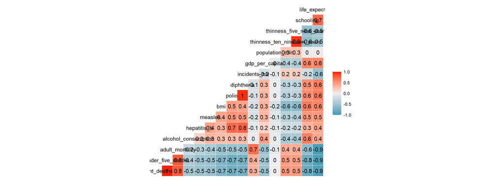

```r
GGally::ggcorr(dados, label = TRUE)
```

> Correlação de variáveis dos países desenvolvidos

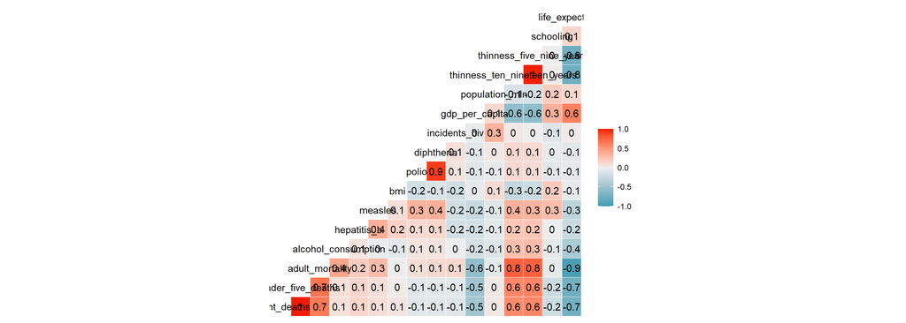

```r
GGally::ggcorr(dados_desenvolvido, label = TRUE)
```

> Correlação de variáveis dos países sub-desenvolvidos

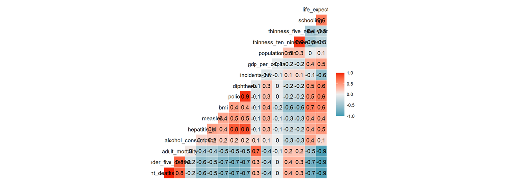

```r
GGally::ggcorr(dados_subdesenvolvido, label = TRUE)
```

> Base de dados transformada para séries temporais e criação das receitas com as variáveis observadas no gráfico de correlação.

```r
nested_data <- dados_desenvolvido  %>%
  extend_timeseries(.id_var = country,
                    .date_var = year,
                    .length_future = 4) %>%
  nest_timeseries(.id_var = country,
                  .length_future = 2*2) %>%
  split_nested_timeseries(.length_test = 3)
```

> Cria uma receita para o modelo de regressão prophet, especificando a fórmula e usando os dados de treinamento das séries temporais aninhadas.

```r
rec_prophet <- recipe(life_expectancy ~  year + infant_deaths + under_five_deaths + adult_mortality + gdp_per_capita + thinness_five_nine_years + thinness_ten_nineteen_years, extract_nested_train_split(nested_data))
```

> Cria uma receita rec_prophetxgb para o modelo prophet-xgboost, com termos de Fourier, codificação dummy, remoção de características de variância zero e remoção de características com base em correlação.

```r
rec_prophetxgb <- recipe(life_expectancy ~  year + infant_deaths + under_five_deaths + adult_mortality + gdp_per_capita + thinness_five_nine_years + thinness_ten_nineteen_years, extract_nested_train_split(nested_data)) %>%
  step_timeseries_signature(year) %>%
  step_fourier(year, period = c(1, 3), K = 4) %>%
  step_dummy(all_nominal()) %>%
  step_zv() %>%
  step_corr()
```

> Cria uma receita rec_rf para o modelo de floresta aleatória usando os dados de treinamento das séries temporais aninhadas.

```r
rec_rf <- recipe(life_expectancy ~  year + infant_deaths + under_five_deaths + adult_mortality + gdp_per_capita + thinness_five_nine_years + thinness_ten_nineteen_years, extract_nested_train_split(nested_data))
```

> Com as receitas criadas montamos os workflows.

```r
wflw_prophet <- workflow() %>%
  add_model(prophet_reg("regression", seasonality_yearly = FALSE) %>%
              set_engine("prophet")) %>%
  add_recipe(rec_prophet)

wflw_prophetxgb <- workflow() %>%
  add_model(prophet_boost() %>%
              set_engine("prophet_xgboost",
                         yearly.seasonality = FALSE)) %>%
  add_recipe(rec_prophetxgb)

wflw_rf <- workflow() %>%
  add_model(rand_forest("regression", trees = 100000) %>%
              set_engine("randomForest")) %>%
  add_recipe(rec_rf)
```

> Treinamento dos modelos.

```r
nested_modeltime_tbl <- modeltime_nested_fit(
  nested_data = nested_data,
  wflw_prophet,
  wflw_rf,
  wflw_prophetxgb)
```

> Avaliação da acurácia dos modelos por país. Visualização em tabela e gráfico.

```r
nested_modeltime_tbl %>%
  extract_nested_test_accuracy() %>%
  filter(startsWith(country, 'N') | startsWith(country, 'J')) %>%
  group_by(country) %>%
  table_modeltime_accuracy(.interactive = FALSE)
```

Accuracy Table

| .model_id | .model_desc | .type | mae | mape | mase | smape | rmse | rsq |
| --- | --- | --- | --- | --- | --- | --- | --- | --- |
| Japan |  |  |  |  |  |  |  |  |
| 1 | PROPHET W REGRESSORS | Test | 0.40 | 0.48 | 1.60 | 0.48 | 0.41 | 0.98 |
| 2 | RANDOMFOREST | Test | 0.72 | 0.86 | 2.87 | 0.86 | 0.75 | NA |
| 3 | PROPHET W XGBOOST ERRORS | Test | 0.60 | 0.72 | 2.42 | 0.73 | 0.68 | 0.34 |
| Netherlands |  |  |  |  |  |  |  |  |
| 1 | PROPHET W REGRESSORS | Test | 0.24 | 0.29 | 0.80 | 0.29 | 0.28 | 0.01 |
| 2 | RANDOMFOREST | Test | 0.63 | 0.77 | 2.09 | 0.77 | 0.65 | 0.03 |
| 3 | PROPHET W XGBOOST ERRORS | Test | 0.18 | 0.22 | 0.58 | 0.21 | 0.24 | 0.56 |
| Norway |  |  |  |  |  |  |  |  |
| 1 | PROPHET W REGRESSORS | Test | 0.14 | 0.17 | 0.56 | 0.17 | 0.14 | 1.00 |
| 2 | RANDOMFOREST | Test | 1.10 | 1.34 | 4.40 | 1.35 | 1.12 | 0.74 |
| 3 | PROPHET W XGBOOST ERRORS | Test | 0.13 | 0.16 | 0.52 | 0.16 | 0.14 | 0.95 |
| New Zealand |  |  |  |  |  |  |  |  |
| 1 | PROPHET W REGRESSORS | Test | 0.41 | 0.51 | 8.27 | 0.51 | 0.46 | 0.68 |
| 2 | RANDOMFOREST | Test | 0.61 | 0.75 | 12.26 | 0.76 | 0.61 | NA |
| 3 | PROPHET W XGBOOST ERRORS | Test | 0.14 | 0.17 | 2.74 | 0.17 | 0.14 | 1.00 |

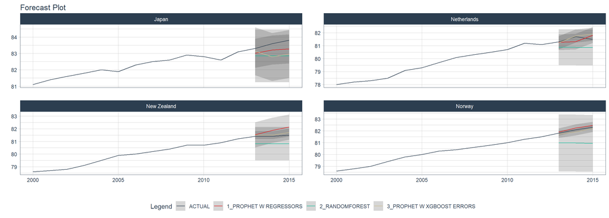

```r
nested_modeltime_tbl %>%
  extract_nested_test_forecast() %>%
  filter(startsWith(country, 'N') | startsWith(country, 'J')) %>%
  group_by(country) %>%
  plot_modeltime_forecast(
    .facet_ncol  = 2,
    .interactive = FALSE
  )
```

> Criação de dois novos modelos preditores utilizando ensemble, um pela média aritmética dos outros modelos e outro pela média ponderada dos mesmos.

```r
nested_ensemble_1_tbl <- nested_modeltime_tbl %>%
  ensemble_nested_average(
    type           = "mean",
    keep_submodels = TRUE)

nested_ensemble_2_tbl <- nested_ensemble_1_tbl %>%
  ensemble_nested_weighted(
    loadings        = c(5,2,1),
    metric          = "rmse",
    model_ids       = c(1,2,3),
    scale_loadings  = TRUE,
    control         = control_nested_fit(allow_par = FALSE, verbose = TRUE))
```

> Visualização dos 5 modelos criados (prophet com regressores, prophet com xgboost, floresta aleatória, média aritmética e média ponderada dos modelos).

```r
nested_ensemble_2_tbl %>%
  extract_nested_test_accuracy() %>%
  group_by(country) %>%
  mutate_at(vars(-country, -.model_id, -.model_desc, -.type), funs(round(., 2))) %>%
  kable("html") %>%
  kable_styling() %>%
  scroll_box(width = "100%", height = "500px")
```

| country | .model_id | .model_desc | .type | mae | mape | mase | smape | rmse | rsq |
| --- | --- | --- | --- | --- | --- | --- | --- | --- | --- |
| Australia | 1 | PROPHET W REGRESSORS | Test | 0.70 | 0.85 | 4.66 | 0.85 | 0.88 | 0.97 |
| Australia | 2 | RANDOMFOREST | Test | 0.48 | 0.58 | 3.17 | 0.58 | 0.49 | 0.57 |
| Australia | 3 | PROPHET W XGBOOST ERRORS | Test | 0.04 | 0.05 | 0.26 | 0.05 | 0.06 | 0.96 |
| Australia | 4 | ENSEMBLE (MEAN): 3 MODELS | Test | 0.37 | 0.45 | 2.45 | 0.45 | 0.43 | 0.97 |
| Australia | 5 | ENSEMBLE (WEIGHTED): 3 MODELS | Test | 0.18 | 0.22 | 1.18 | 0.22 | 0.19 | 0.96 |
| Austria | 1 | PROPHET W REGRESSORS | Test | 0.11 | 0.13 | 0.31 | 0.13 | 0.11 | 1.00 |
| Austria | 2 | RANDOMFOREST | Test | 0.53 | 0.65 | 1.51 | 0.65 | 0.56 | 0.08 |
| Austria | 3 | PROPHET W XGBOOST ERRORS | Test | 0.25 | 0.31 | 0.71 | 0.31 | 0.25 | 0.27 |
| Austria | 4 | ENSEMBLE (MEAN): 3 MODELS | Test | 0.17 | 0.21 | 0.48 | 0.21 | 0.20 | 0.64 |
| Austria | 5 | ENSEMBLE (WEIGHTED): 3 MODELS | Test | 0.07 | 0.08 | 0.19 | 0.08 | 0.07 | 0.86 |
| Belgium | 1 | PROPHET W REGRESSORS | Test | 1435177.85 | 1780617.68 | 2870355.70 | 67.20 | 2485800.19 | 0.82 |
| Belgium | 2 | RANDOMFOREST | Test | 0.68 | 0.84 | 1.36 | 0.84 | 0.74 | 0.82 |
| Belgium | 3 | PROPHET W XGBOOST ERRORS | Test | 0.14 | 0.17 | 0.27 | 0.17 | 0.16 | 0.70 |
| Belgium | 4 | ENSEMBLE (MEAN): 3 MODELS | Test | 478392.63 | 593539.24 | 956785.25 | 66.89 | 828600.01 | 0.82 |
| Belgium | 5 | ENSEMBLE (WEIGHTED): 3 MODELS | Test | 179397.30 | 222577.30 | 358794.61 | 66.83 | 310724.99 | 0.82 |
| Bulgaria | 1 | PROPHET W REGRESSORS | Test | 0.89 | 1.19 | 3.55 | 1.18 | 0.99 | 0.73 |
| Bulgaria | 2 | RANDOMFOREST | Test | 0.75 | 1.01 | 3.01 | 1.01 | 0.77 | 0.48 |
| Bulgaria | 3 | PROPHET W XGBOOST ERRORS | Test | 0.57 | 0.76 | 2.26 | 0.76 | 0.61 | 0.68 |
| Bulgaria | 4 | ENSEMBLE (MEAN): 3 MODELS | Test | 0.39 | 0.52 | 1.57 | 0.52 | 0.40 | 0.70 |
| Bulgaria | 5 | ENSEMBLE (WEIGHTED): 3 MODELS | Test | 0.42 | 0.56 | 1.67 | 0.56 | 0.42 | 0.68 |
| Canada | 1 | PROPHET W REGRESSORS | Test | 0.93 | 1.13 | 9.25 | 1.14 | 1.02 | 0.10 |
| Canada | 2 | RANDOMFOREST | Test | 0.54 | 0.66 | 5.40 | 0.66 | 0.55 | NA |
| Canada | 3 | PROPHET W XGBOOST ERRORS | Test | 0.30 | 0.37 | 3.04 | 0.37 | 0.31 | 1.00 |
| Canada | 4 | ENSEMBLE (MEAN): 3 MODELS | Test | 0.39 | 0.47 | 3.87 | 0.47 | 0.41 | 0.34 |
| Canada | 5 | ENSEMBLE (WEIGHTED): 3 MODELS | Test | 0.08 | 0.09 | 0.77 | 0.09 | 0.09 | 0.84 |
| Croatia | 1 | PROPHET W REGRESSORS | Test | 1.61 | 2.08 | 5.37 | 2.06 | 1.71 | 0.48 |
| Croatia | 2 | RANDOMFOREST | Test | 0.69 | 0.90 | 2.31 | 0.90 | 0.71 | 0.00 |
| Croatia | 3 | PROPHET W XGBOOST ERRORS | Test | 0.21 | 0.27 | 0.70 | 0.27 | 0.30 | 0.25 |
| Croatia | 4 | ENSEMBLE (MEAN): 3 MODELS | Test | 0.38 | 0.49 | 1.25 | 0.49 | 0.44 | 0.42 |
| Croatia | 5 | ENSEMBLE (WEIGHTED): 3 MODELS | Test | 0.17 | 0.22 | 0.56 | 0.22 | 0.25 | 0.33 |

[output cut: 155 more lines]

> Visualização do melhor modelo por país entre os 5 modelos criados (prophet com regressores, prophet com xgboost, floresta aleatória, média aritmética e média ponderada dos modelos).

```r
best_nested_modeltime_tbl <- nested_ensemble_2_tbl %>%
  modeltime_nested_select_best(
    metric                = "rmse",
    minimize              = TRUE,
    filter_test_forecasts = TRUE)

best_nested_modeltime_tbl %>%
  extract_nested_best_model_report() %>%
  mutate_at(vars(-country, -.model_id, -.model_desc, -.type), funs(round(., 2))) %>%
  kable("html") %>%
  kable_styling() %>%
  scroll_box(width = "100%", height = "500px")
```

| country | .model_id | .model_desc | .type | mae | mape | mase | smape | rmse | rsq |
| --- | --- | --- | --- | --- | --- | --- | --- | --- | --- |
| Hungary | 3 | PROPHET W XGBOOST ERRORS | Test | 0.38 | 0.50 | 1.89 | 0.50 | 0.44 | 0.03 |
| Ireland | 3 | PROPHET W XGBOOST ERRORS | Test | 0.07 | 0.08 | 0.22 | 0.08 | 0.09 | 1.00 |
| France | 5 | ENSEMBLE (WEIGHTED): 3 MODELS | Test | 0.25 | 0.31 | 0.56 | 0.31 | 0.26 | 0.15 |
| United States | 5 | ENSEMBLE (WEIGHTED): 3 MODELS | Test | 0.07 | 0.09 | 0.67 | 0.09 | 0.07 | 0.10 |
| Italy | 5 | ENSEMBLE (WEIGHTED): 3 MODELS | Test | 0.28 | 0.34 | 0.55 | 0.34 | 0.29 | 0.01 |
| Cyprus | 5 | ENSEMBLE (WEIGHTED): 3 MODELS | Test | 0.07 | 0.09 | 0.37 | 0.09 | 0.08 | 1.00 |
| Estonia | 5 | ENSEMBLE (WEIGHTED): 3 MODELS | Test | 0.29 | 0.37 | 0.82 | 0.37 | 0.33 | 0.43 |
| Slovak Republic | 5 | ENSEMBLE (WEIGHTED): 3 MODELS | Test | 0.10 | 0.13 | 0.32 | 0.13 | 0.10 | 0.69 |
| Japan | 1 | PROPHET W REGRESSORS | Test | 0.40 | 0.48 | 1.60 | 0.48 | 0.41 | 0.98 |
| Luxembourg | 1 | PROPHET W REGRESSORS | Test | 0.17 | 0.21 | 0.68 | 0.21 | 0.19 | 0.99 |
| Lithuania | 1 | PROPHET W REGRESSORS | Test | 0.14 | 0.18 | 0.34 | 0.18 | 0.19 | 0.69 |
| Germany | 5 | ENSEMBLE (WEIGHTED): 3 MODELS | Test | 0.20 | 0.24 | 0.36 | 0.24 | 0.24 | 0.22 |
| Bulgaria | 4 | ENSEMBLE (MEAN): 3 MODELS | Test | 0.39 | 0.52 | 1.57 | 0.52 | 0.40 | 0.70 |
| Malta | 3 | PROPHET W XGBOOST ERRORS | Test | 0.34 | 0.42 | 1.70 | 0.42 | 0.37 | 0.98 |
| Netherlands | 5 | ENSEMBLE (WEIGHTED): 3 MODELS | Test | 0.17 | 0.21 | 0.56 | 0.21 | 0.18 | 0.38 |
| Finland | 3 | PROPHET W XGBOOST ERRORS | Test | 0.13 | 0.16 | 0.51 | 0.16 | 0.18 | 0.88 |
| Poland | 3 | PROPHET W XGBOOST ERRORS | Test | 0.17 | 0.21 | 0.47 | 0.21 | 0.22 | 0.80 |
| Austria | 5 | ENSEMBLE (WEIGHTED): 3 MODELS | Test | 0.07 | 0.08 | 0.19 | 0.08 | 0.07 | 0.86 |
| Slovenia | 3 | PROPHET W XGBOOST ERRORS | Test | 0.23 | 0.28 | 0.41 | 0.28 | 0.32 | 0.60 |
| Israel | 5 | ENSEMBLE (WEIGHTED): 3 MODELS | Test | 0.18 | 0.21 | 1.75 | 0.21 | 0.19 | 0.07 |
| Norway | 3 | PROPHET W XGBOOST ERRORS | Test | 0.13 | 0.16 | 0.52 | 0.16 | 0.14 | 0.95 |
| Iceland | 5 | ENSEMBLE (WEIGHTED): 3 MODELS | Test | 0.39 | 0.47 | 0.65 | 0.47 | 0.42 | 0.23 |
| Switzerland | 5 | ENSEMBLE (WEIGHTED): 3 MODELS | Test | 0.18 | 0.22 | 0.51 | 0.22 | 0.19 | 0.16 |
| Portugal | 4 | ENSEMBLE (MEAN): 3 MODELS | Test | 0.21 | 0.26 | 1.07 | 0.26 | 0.35 | 0.67 |
| Sweden | 5 | ENSEMBLE (WEIGHTED): 3 MODELS | Test | 0.12 | 0.14 | 0.58 | 0.14 | 0.15 | 0.33 |
| New Zealand | 4 | ENSEMBLE (MEAN): 3 MODELS | Test | 0.06 | 0.07 | 1.13 | 0.07 | 0.07 | 0.82 |
| Denmark | 4 | ENSEMBLE (MEAN): 3 MODELS | Test | 0.18 | 0.22 | 0.89 | 0.22 | 0.22 | 0.75 |
| Croatia | 5 | ENSEMBLE (WEIGHTED): 3 MODELS | Test | 0.17 | 0.22 | 0.56 | 0.22 | 0.25 | 0.33 |
| Belgium | 3 | PROPHET W XGBOOST ERRORS | Test | 0.14 | 0.17 | 0.27 | 0.17 | 0.16 | 0.70 |
| United Kingdom | 5 | ENSEMBLE (WEIGHTED): 3 MODELS | Test | 0.24 | 0.30 | 0.80 | 0.30 | 0.27 | 0.45 |
| Spain | 5 | ENSEMBLE (WEIGHTED): 3 MODELS | Test | 0.37 | 0.45 | 1.50 | 0.45 | 0.46 | 0.20 |
| Romania | 5 | ENSEMBLE (WEIGHTED): 3 MODELS | Test | 0.54 | 0.73 | 5.44 | 0.72 | 0.57 | 0.90 |
| Australia | 3 | PROPHET W XGBOOST ERRORS | Test | 0.04 | 0.05 | 0.26 | 0.05 | 0.06 | 0.96 |
| Latvia | 3 | PROPHET W XGBOOST ERRORS | Test | 0.11 | 0.15 | 0.45 | 0.15 | 0.14 | 0.87 |
| Greece | 3 | PROPHET W XGBOOST ERRORS | Test | 0.30 | 0.36 | 1.19 | 0.37 | 0.32 | 0.19 |
| Canada | 5 | ENSEMBLE (WEIGHTED): 3 MODELS | Test | 0.08 | 0.09 | 0.77 | 0.09 | 0.09 | 0.84 |
| Czechia | 5 | ENSEMBLE (WEIGHTED): 3 MODELS | Test | 0.17 | 0.21 | 0.42 | 0.21 | 0.21 | 0.50 |

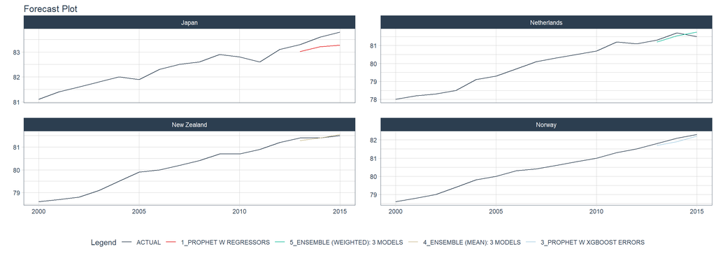

```r
best_nested_modeltime_tbl %>%
  extract_nested_test_forecast() %>%
  filter(startsWith(country, 'N') | startsWith(country, 'J')) %>%
  group_by(country) %>%
  plot_modeltime_forecast(
    .facet_ncol  = 2,
    .interactive = FALSE,
    .conf_interval_show = FALSE)
```

> Fazendo o mesmo para os países sub-desenvolvidos.

```r
nested_data <- dados_subdesenvolvido  %>%
  extend_timeseries(.id_var = country,
                    .date_var = year,
                    .length_future = 4) %>%
  nest_timeseries(.id_var = country,
                  .length_future = 2*2) %>%
  split_nested_timeseries(.length_test = 3)

rec_prophet <- recipe(life_expectancy ~  year + infant_deaths + under_five_deaths + adult_mortality + bmi + polio + diphtheria + incidents_hiv + schooling, extract_nested_train_split(nested_data))

rec_prophetxgb <- recipe(life_expectancy ~  year + infant_deaths + under_five_deaths + adult_mortality + bmi + polio + diphtheria + incidents_hiv + schooling, extract_nested_train_split(nested_data)) %>%
  step_timeseries_signature(year) %>%
  step_fourier(year, period = c(9,45), K = 4) %>%
  step_dummy(all_nominal()) %>%
  step_zv() %>%
  step_corr()

rec_rf <- recipe(life_expectancy ~  year + infant_deaths + under_five_deaths + adult_mortality + bmi + polio + diphtheria + incidents_hiv + schooling, extract_nested_train_split(nested_data))

wflw_prophet <- workflow() %>%
  add_model(prophet_reg("regression", seasonality_yearly = FALSE) %>%
              set_engine("prophet")) %>%
  add_recipe(rec_prophet)

wflw_prophetxgb <- workflow() %>%
  add_model(prophet_boost() %>%
              set_engine("prophet_xgboost",
                         yearly.seasonality = FALSE)) %>%
  add_recipe(rec_prophetxgb)

wflw_rf <- workflow() %>%
  add_model(rand_forest("regression", trees = 100000) %>%
              set_engine("randomForest")) %>%
  add_recipe(rec_rf)

nested_modeltime_tbl <- modeltime_nested_fit(
  nested_data = nested_data,
  wflw_prophet,
  wflw_rf,
  wflw_prophetxgb)

nested_ensemble_1_tbl <- nested_modeltime_tbl %>%
  ensemble_nested_average(
    type           = "mean",
    keep_submodels = TRUE)

accuracy_rmse <- nested_ensemble_1_tbl %>%
  extract_nested_test_accuracy()

nested_ensemble_2_tbl <- nested_ensemble_1_tbl %>%
  ensemble_nested_weighted(
    loadings        = c(5,2,1),
    metric          = "rmse",
    model_ids       = c(1,2,3),
    scale_loadings  = TRUE,
    control         = control_nested_fit(allow_par = FALSE, verbose = TRUE))
```

```r
best_nested_modeltime_tbl <- nested_ensemble_2_tbl %>%
  modeltime_nested_select_best(
    metric                = "rmse",
    minimize              = TRUE,
    filter_test_forecasts = TRUE)

best_nested_modeltime_tbl %>%
  extract_nested_best_model_report() %>%
  mutate_at(vars(-country, -.model_id, -.model_desc, -.type), funs(round(., 2))) %>%
  kable("html") %>%
  kable_styling() %>%
  scroll_box(width = "100%", height = "500px")
```

| country | .model_id | .model_desc | .type | mae | mape | mase | smape | rmse | rsq |
| --- | --- | --- | --- | --- | --- | --- | --- | --- | --- |
| Afghanistan | 3 | PROPHET W XGBOOST ERRORS | Test | 0.17 | 0.27 | 0.38 | 0.27 | 0.19 | 0.99 |
| Solomon Islands | 3 | PROPHET W XGBOOST ERRORS | Test | 0.02 | 0.03 | 0.06 | 0.03 | 0.02 | 1.00 |
| Congo, Dem. Rep. | 5 | ENSEMBLE (WEIGHTED): 3 MODELS | Test | 0.09 | 0.16 | 0.20 | 0.16 | 0.12 | 0.97 |
| Honduras | 3 | PROPHET W XGBOOST ERRORS | Test | 0.07 | 0.09 | 0.33 | 0.09 | 0.08 | 0.99 |
| Togo | 5 | ENSEMBLE (WEIGHTED): 3 MODELS | Test | 0.18 | 0.30 | 0.51 | 0.30 | 0.23 | 0.99 |
| Costa Rica | 3 | PROPHET W XGBOOST ERRORS | Test | 0.07 | 0.09 | 0.35 | 0.09 | 0.08 | 0.96 |
| Malawi | 5 | ENSEMBLE (WEIGHTED): 3 MODELS | Test | 0.28 | 0.46 | 0.27 | 0.46 | 0.31 | 1.00 |
| Zimbabwe | 5 | ENSEMBLE (WEIGHTED): 3 MODELS | Test | 0.64 | 1.10 | 0.49 | 1.11 | 0.65 | 1.00 |
| Cabo Verde | 3 | PROPHET W XGBOOST ERRORS | Test | 0.13 | 0.18 | 0.65 | 0.18 | 0.14 | 0.96 |
| Singapore | 3 | PROPHET W XGBOOST ERRORS | Test | 0.10 | 0.13 | 0.41 | 0.13 | 0.10 | 1.00 |
| Liberia | 3 | PROPHET W XGBOOST ERRORS | Test | 0.11 | 0.17 | 0.19 | 0.17 | 0.11 | 1.00 |
| Somalia | 3 | PROPHET W XGBOOST ERRORS | Test | 0.10 | 0.18 | 0.25 | 0.18 | 0.13 | 1.00 |
| Iran, Islamic Rep. | 5 | ENSEMBLE (WEIGHTED): 3 MODELS | Test | 0.10 | 0.13 | 0.34 | 0.13 | 0.14 | 1.00 |
| Vanuatu | 3 | PROPHET W XGBOOST ERRORS | Test | 0.00 | 0.01 | 0.02 | 0.01 | 0.00 | 1.00 |
| Colombia | 3 | PROPHET W XGBOOST ERRORS | Test | 0.04 | 0.05 | 0.19 | 0.05 | 0.06 | 0.99 |
| Mali | 1 | PROPHET W REGRESSORS | Test | 0.05 | 0.09 | 0.12 | 0.09 | 0.06 | 0.99 |
| Uzbekistan | 5 | ENSEMBLE (WEIGHTED): 3 MODELS | Test | 0.03 | 0.04 | 0.12 | 0.04 | 0.04 | 0.99 |
| Bahamas, The | 3 | PROPHET W XGBOOST ERRORS | Test | 0.19 | 0.25 | 0.74 | 0.25 | 0.23 | 0.99 |
| Djibouti | 3 | PROPHET W XGBOOST ERRORS | Test | 0.55 | 0.87 | 0.58 | 0.87 | 0.64 | 0.99 |
| Mauritania | 3 | PROPHET W XGBOOST ERRORS | Test | 0.13 | 0.20 | 0.52 | 0.20 | 0.14 | 0.95 |
| Guatemala | 3 | PROPHET W XGBOOST ERRORS | Test | 0.07 | 0.10 | 0.20 | 0.10 | 0.08 | 0.99 |
| Cambodia | 5 | ENSEMBLE (WEIGHTED): 3 MODELS | Test | 0.11 | 0.16 | 0.31 | 0.16 | 0.13 | 0.90 |
| El Salvador | 3 | PROPHET W XGBOOST ERRORS | Test | 0.06 | 0.09 | 0.25 | 0.09 | 0.07 | 0.99 |
| Dominican Republic | 3 | PROPHET W XGBOOST ERRORS | Test | 0.07 | 0.09 | 0.33 | 0.09 | 0.08 | 0.99 |
| Burundi | 5 | ENSEMBLE (WEIGHTED): 3 MODELS | Test | 0.04 | 0.06 | 0.08 | 0.06 | 0.04 | 0.99 |
| Jamaica | 2 | RANDOMFOREST | Test | 0.03 | 0.05 | 0.69 | 0.05 | 0.06 | 0.25 |
| Eritrea | 3 | PROPHET W XGBOOST ERRORS | Test | 0.17 | 0.26 | 0.34 | 0.26 | 0.18 | 1.00 |
| Eswatini | 3 | PROPHET W XGBOOST ERRORS | Test | 1.19 | 2.21 | 0.64 | 2.23 | 1.25 | 1.00 |
| Grenada | 3 | PROPHET W XGBOOST ERRORS | Test | 0.10 | 0.14 | 1.03 | 0.14 | 0.10 | 1.00 |
| Fiji | 5 | ENSEMBLE (WEIGHTED): 3 MODELS | Test | 0.04 | 0.06 | 0.86 | 0.06 | 0.04 | 0.68 |

[output cut: 112 more lines]

> Os modelos nem sempre irão retornar resultados bons, existem casos onde os países estão classificados como países sub-desenvolvidos porém suas preditoras possuem a “qualidade” de países desenvolvidos, e como o modelo está treinando com as variáveis de maior correlação dos países sub-desenvolvidos ele não consegue se adaptar a esses países, causando distorções nos resultados.

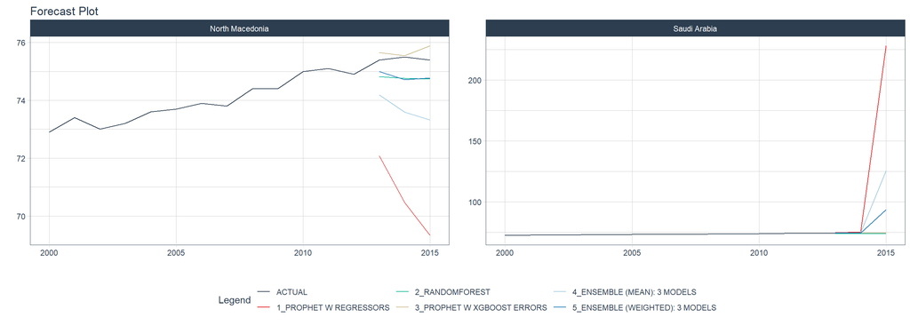

```r
nested_ensemble_2_tbl %>%
  extract_nested_test_forecast() %>%
  filter(startsWith(country, 'Saudi Arabia') | startsWith(country, 'North Macedonia')) %>%
  group_by(country) %>%
  plot_modeltime_forecast(
    .facet_ncol  = 2,
    .interactive = FALSE,
    .conf_interval_show = FALSE)
```

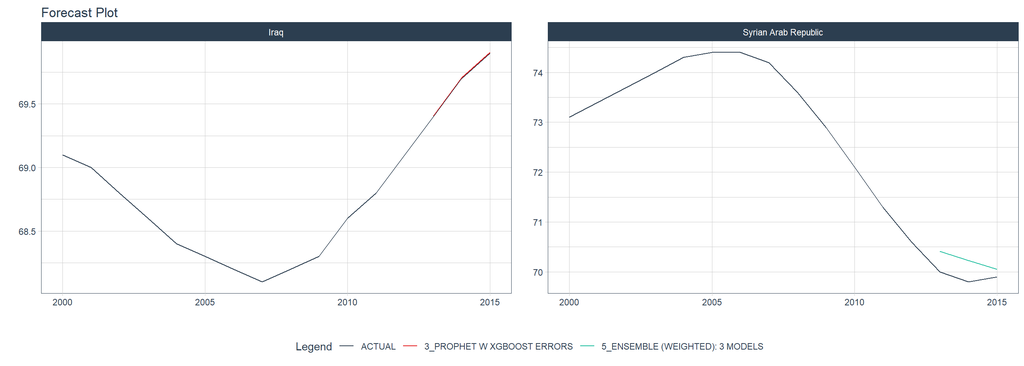

```r
best_nested_modeltime_tbl %>%
  extract_nested_test_forecast() %>%
  filter(startsWith(country, 'Iraq') | startsWith(country, 'Syrian')) %>%
  group_by(country) %>%
  plot_modeltime_forecast(
    .facet_ncol  = 2,
    .interactive = FALSE,
    .conf_interval_show = FALSE)
```

#### 4. Análise dos dados não supervisionada

> Será aplicado o método de PCA para visualização de quais variáveis fazem parte das componentes principais de ambas as bases de dados (países desenvolvidos e países sub-desenvolvidos), novamente a divisão foi feita por conta da diferença de correlação de variáveis entre os dois tipos de países.

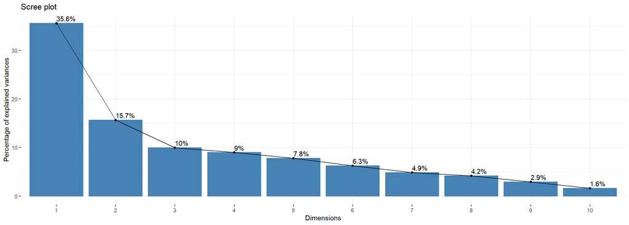

```r
dados_pca_desenvolvido <- dados_desenvolvido %>%
                            group_by(country) %>%
                            summarise_at(vars(infant_deaths, under_five_deaths, adult_mortality, alcohol_consumption, hepatitis_b, measles, bmi, polio, diphtheria, incidents_hiv, gdp_per_capita, population_mln, thinness_ten_nineteen_years, thinness_five_nine_years, schooling, life_expectancy), list(name = mean))

dados_pca_desenvolvido <- dados_pca_desenvolvido %>%
                            remove_rownames %>%
                            column_to_rownames(var="country")

X <- scale(dados_pca_desenvolvido, center = TRUE, scale = TRUE)

pca <- prcomp(X)

pca$rotation <- -pca$rotation
pca$x <- -pca$x

Phi <- pca$rotation
Z <- pca$x

fviz_eig(pca, addlabels = TRUE)
```

> Observa-se que para explicar 80% da variância é necessário 6 variáveis.

> É possível então visualizar quais variáveis possuem mais relevância na primeira componente principal

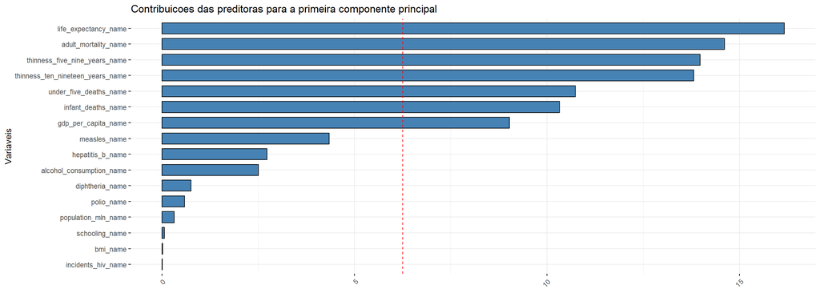

```r
pca %>%
  fviz_contrib(choice = "var", axes = 1, sort.val = "asc",
               fill = "steelblue", color = "black") +
  labs(x = "Variaveis", title = "Contribuicoes das preditoras para a primeira componente principal") +
  coord_flip()
```

> E também possível visualizar quais variáveis possuem mais relevância na segunda componente principal

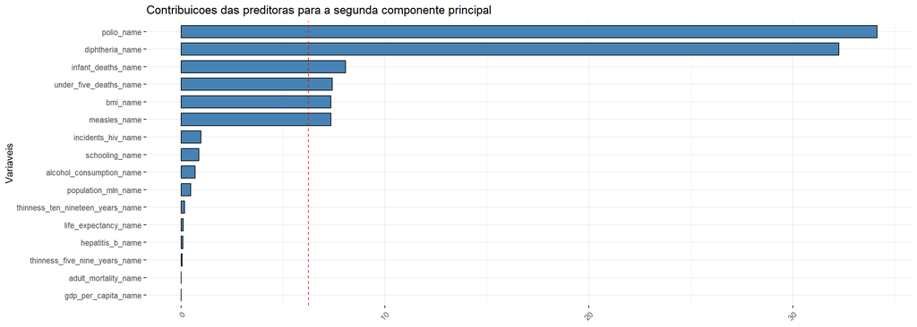

```r
pca %>%
  fviz_contrib(choice = "var", axes = 2, sort.val = "asc",
               fill = "steelblue", color = "black") +
  labs(x = "Variaveis", title = "Contribuicoes das preditoras para a segunda componente principal") +
  coord_flip()
```

> Com isso, cria-se o gráfico de PCA para observar o posicionamento dos países em relação às componentes principais

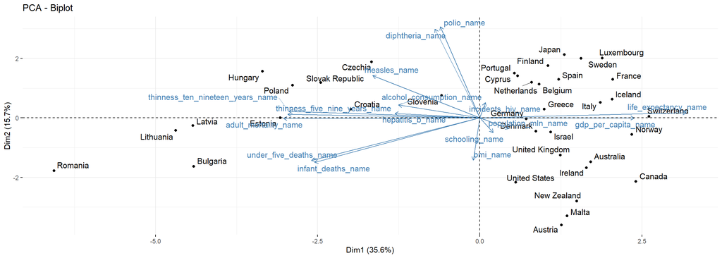

```r
fviz_pca_biplot(pca, repel = TRUE)
```

> Para futura separação em clusters utilizamos o método de cotovelo e silhouette para determinar o número adequado de grupos

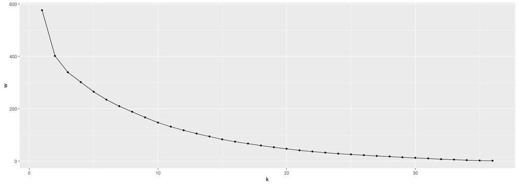

```r
dados_desenvolvido_pad <- dados_pca_desenvolvido %>%
                          scale()

tibble(k = 1:(nrow(dados_pca_desenvolvido)-1)) %>%
  mutate(w = map_dbl(k, ~ kmeans(dados_desenvolvido_pad, centers = .x,
                                 nstart = 1000)$tot.withinss)) %>%
  ggplot(aes(k, w)) +
  geom_point() +
  geom_line()
```

> Pelo método de cotovelo k = 6

```
##   cluster size ave.sil.width
## 1       1    7          0.53
## 2       2    7          0.19
## 3       3    4          0.16
## 4       4    1          0.00
## 5       5    7          0.09
## 6       6   11          0.34
```

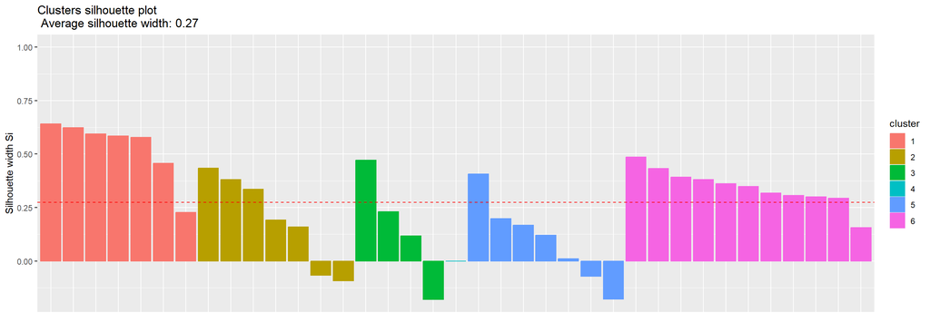

```r
set.seed(111)

descricao <- dados_pca_desenvolvido %>%
  mutate(cluster = factor(kmeans(dados_desenvolvido_pad, centers = 6, nstart = 1000)$cluster))

res_sil <- silhouette(as.numeric(descricao$cluster),
                      dist(dados_desenvolvido_pad)^2)

fviz_silhouette(res_sil)
```

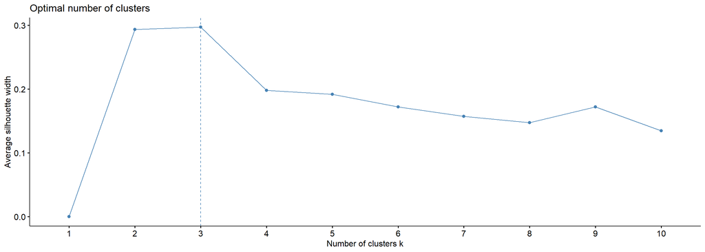

```r
fviz_nbclust(dados_desenvolvido_pad, kmeans, method = "silhouette")
```

> Pelo método de silhouette k = 3

> Apesar do método de silhouette determinar que k = 3 como o objetivo é comparar a separação de clusters do modelo e a separação de regiões feita na base de dados será utilizado k = 6 para que a comparação seja igual. Contudo, já é possível notar que para o modelo só deveriam haver 3 clusters.

> Inicialmente observa-se a separação de acordo com o modelo de PCA.

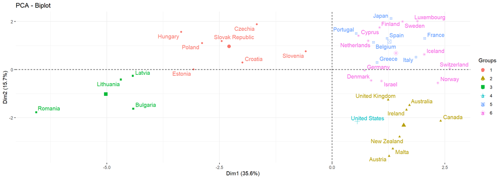

```r
fviz_pca_biplot(pca, repel = TRUE, habillage = descricao$cluster, invisible  = 'var')
```

> Para efeitos de comparação, a separação em regiões feitas na base de dados seria a seguinte.

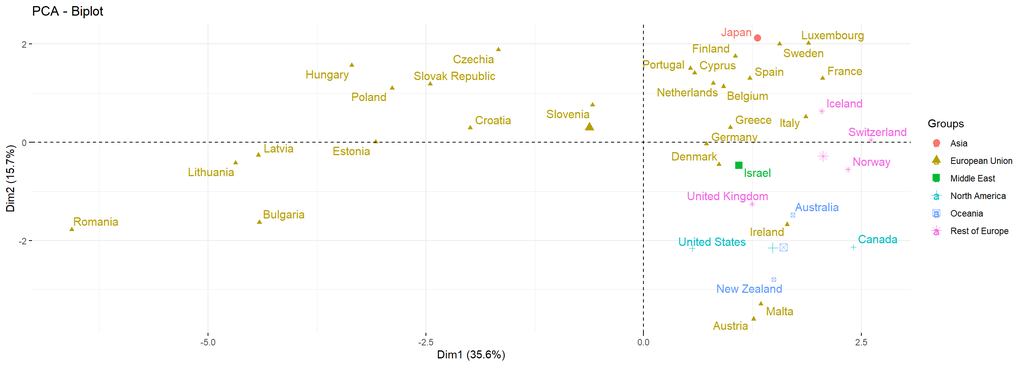

```r
countries <- dados_desenvolvido[order(dados_desenvolvido$year),][1:37,]
countries <- countries[order(countries$country),][1:37,]$region

fviz_pca_biplot(pca, repel = TRUE, habillage = countries, invisible  = 'var')
```

> Todo o processo será refeito para países sub-desenvolvidos.

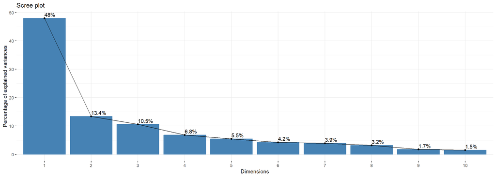

```r
dados_pca_subdesenvolvido <- dados_subdesenvolvido %>%
                            group_by(country) %>%
                            summarise_at(vars(infant_deaths, under_five_deaths, adult_mortality, alcohol_consumption, hepatitis_b, measles, bmi, polio, diphtheria, incidents_hiv, gdp_per_capita, population_mln, thinness_ten_nineteen_years, thinness_five_nine_years, schooling, life_expectancy), list(name = mean))

dados_pca_subdesenvolvido <- dados_pca_subdesenvolvido %>%
                            remove_rownames %>%
                            column_to_rownames(var="country")

X <- scale(dados_pca_subdesenvolvido, center = TRUE, scale = TRUE)

pca <- prcomp(X)

pca$rotation <- -pca$rotation
pca$x <- -pca$x

Phi <- pca$rotation
Z <- pca$x

fviz_eig(pca, addlabels = TRUE)
```

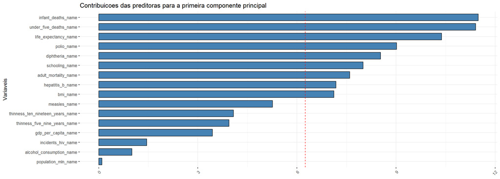

```r
pca %>%
  fviz_contrib(choice = "var", axes = 1, sort.val = "asc",
               fill = "steelblue", color = "black") +
  labs(x = "Variaveis", title = "Contribuicoes das preditoras para a primeira componente principal") +
  coord_flip()
```

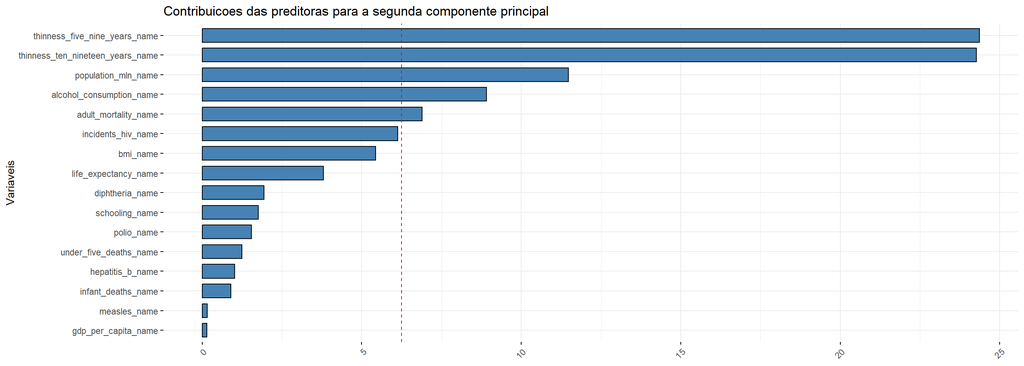

```r
pca %>%
  fviz_contrib(choice = "var", axes = 2, sort.val = "asc",
               fill = "steelblue", color = "black") +
  labs(x = "Variaveis", title = "Contribuicoes das preditoras para a segunda componente principal") +
  coord_flip()
```

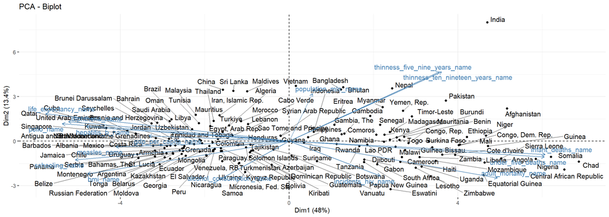

```r
fviz_pca_biplot(pca, repel = TRUE)
```

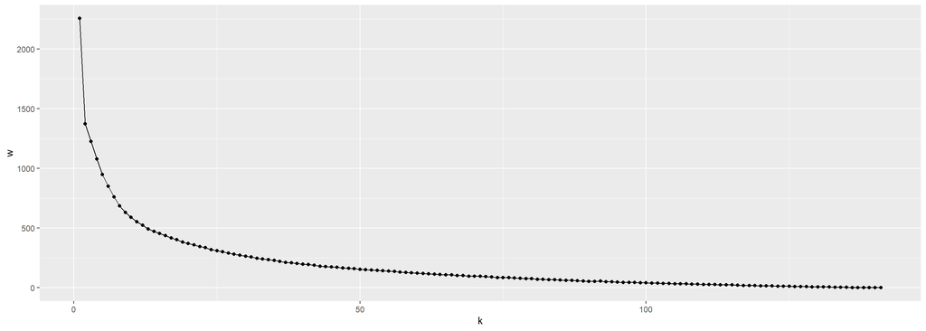

```r
dados_subdesenvolvido_pad <- dados_pca_subdesenvolvido %>%
                          scale()

tibble(k = 1:(nrow(dados_pca_subdesenvolvido)-1)) %>%
  mutate(w = map_dbl(k, ~ kmeans(dados_subdesenvolvido_pad, centers = .x,
                                 nstart = 100)$tot.withinss)) %>%
  ggplot(aes(k, w)) +
  geom_point() +
  geom_line()
```

```
##   cluster size ave.sil.width
## 1       1    2          0.06
## 2       2   27          0.25
## 3       3   26          0.42
## 4       4   70          0.55
## 5       5    9          0.50
## 6       6    8          0.55
```

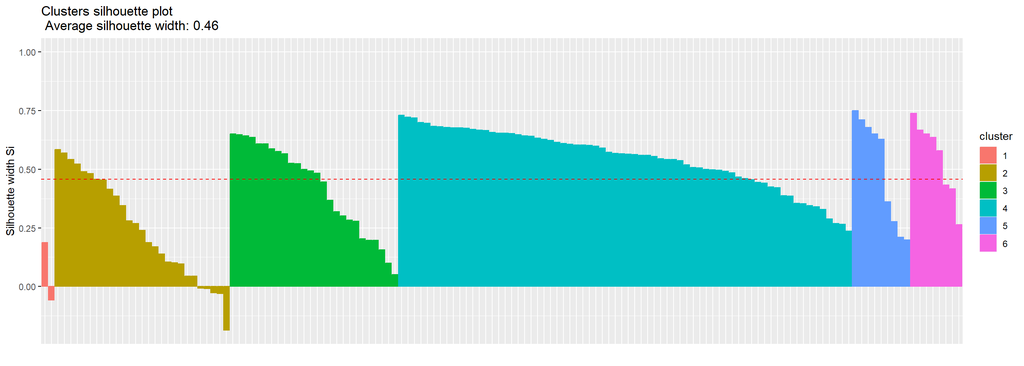

```r
set.seed(111)

descricao <- dados_pca_subdesenvolvido %>%
  mutate(cluster = factor(kmeans(dados_subdesenvolvido_pad, centers = 6, nstart = 1000)$cluster))

res_sil <- silhouette(as.numeric(descricao$cluster),
                      dist(dados_subdesenvolvido_pad)^2)

fviz_silhouette(res_sil)
```

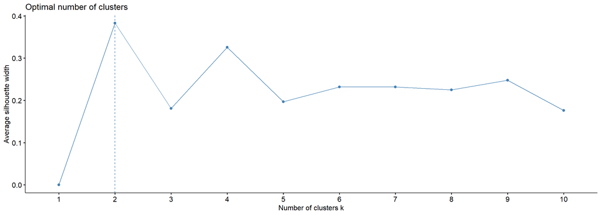

```r
fviz_nbclust(dados_subdesenvolvido_pad, kmeans, method = "silhouette")
```

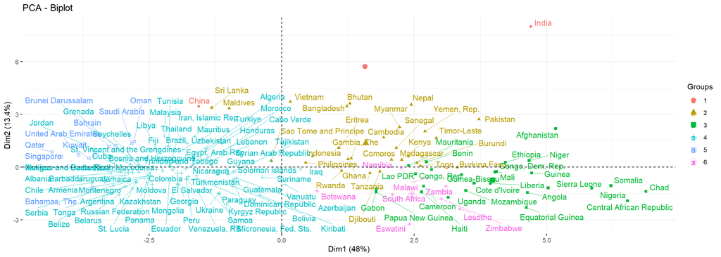

```r
fviz_pca_biplot(pca, repel = TRUE, habillage = descricao$cluster, invisible  = 'var')
```

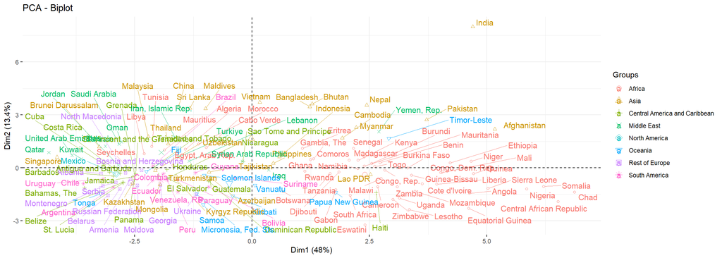

```r
countries <- dados_subdesenvolvido[order(dados_subdesenvolvido$year),][1:142,]
countries <- countries[order(countries$country),][1:142,]$region

fviz_pca_biplot(pca, repel = TRUE, habillage = countries, invisible  = 'var')
```